# Q3

```python
import numpy as np
from sklearn.datasets import make_classification
from sklearn.model_selection import train_test_split
from sklearn.linear_model import LogisticRegression
from sklearn.metrics import roc_curve, precision_recall_curve, auc
import matplotlib.pyplot as plt
from sklearn.metrics import PrecisionRecallDisplay
```

```python
from sklearn.metrics import roc_auc_score

def generate_data(n_samples, imbalance_ratio):
    X, y = make_classification(n_samples=10000, n_features=10, n_classes=2, weights=[imbalance_ratio, 1-imbalance_ratio], random_state=42)
    return X, y

def train_logistic_model(n_samples = 1000, imbalance_ratio = 0.5):
    X,y = generate_data(n_samples, imbalance_ratio)
    X_train, X_test, y_train, y_test = train_test_split(X, y,test_size=0.3, random_state=42)
    clf = LogisticRegression(random_state=42)
    clf.fit(X_train, y_train)
    y_prob = clf.predict_proba(X_test)[:, 1]
    fpr, tpr, _ = roc_curve(y_test,  y_prob)
    auc = round(roc_auc_score(y_test, y_prob),3)

    fig, axs = plt.subplots(1, 2, figsize=(10, 5))
    axs[0].plot(fpr, tpr, label = "AUC="+str(auc))
    axs[0].legend(loc="lower right")
    axs[0].set_ylabel('True Positive Rate')
    axs[0].set_xlabel('False Positive Rate')
    axs[0].set_title('ROC curve with imbalance ratio as ' + str(imbalance_ratio))

    display = PrecisionRecallDisplay.from_estimator(clf, X_test, y_test, name='Logistic Regression', ax = axs[1])
    axs[1].set_title("Precision-Recall curve with imbalance ratio as " + str(imbalance_ratio))
    plt.show()
```

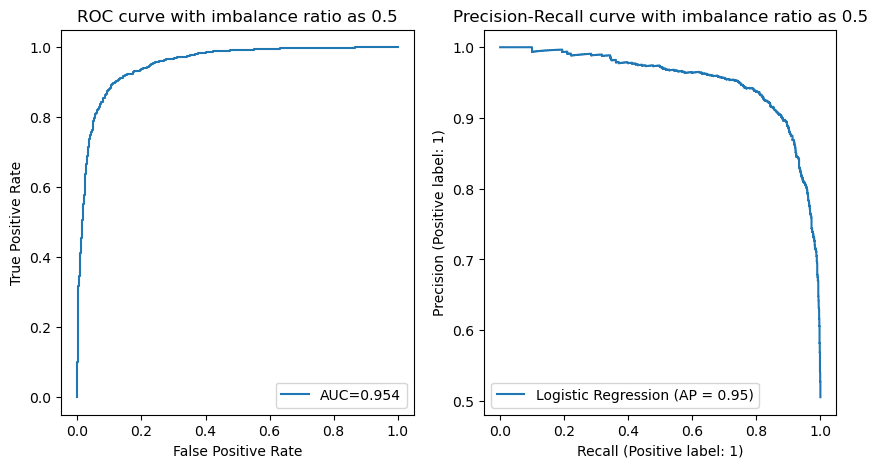

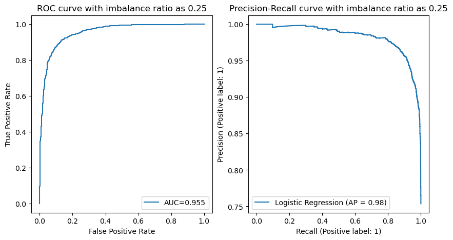

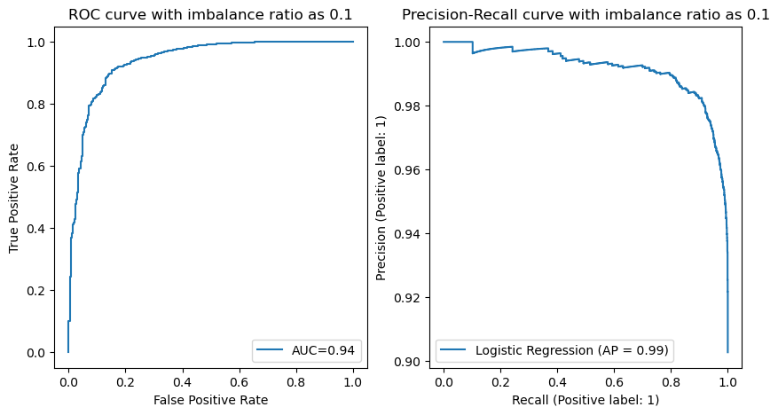

```python
for i in [0.5,0.25,0.1]:
    train_logistic_model(imbalance_ratio = i)
```

The ROC curve plots the True Positive Rate against the False Positive Rate for different thresholds. It is insensitive to class imbalance. A model can has a high AUC even when it performs poorly on the minority class.

PR curve plots the Precision against the Recall for different thresholds. The PR curve is sensitive to class imbalance. A model with high precision and recall on the minority class will have a high PR curve, even if it has low precision and recall on the majority class.

In summary, when the dataset is unbalanced, the PR curve provides a more insights on model performance than the ROC curve, as it takes into account the performance of the model on the minority class. The PR curve would skew towards the minority class to provide a reflective measure